# Project Wrangle and Analyze Twitter Data by Jeremy Meguira

## 9/11/18

The goal of this project is to get practice gathering data from different sources using a variety of methods, clean the data accounting for quality and tidyness, and produce some basic visualizations and insights into the dataset once this has been completed. The data I will be working with is associated with the WeRateDogs twitter account [WeRateDogs twitter account](https://twitter.com/dog_rates).

### Gathering Data

#### WeRateDogs Twitter Archive

This file is provided in the project specifications. In order to gather I simply have to import it into a dataframe within the notebook after downloading it.

```python
#import packages

import pandas as pd
import numpy as np
import requests
import tweepy
import json
import time
```

```python
#pull data from downloaded csv

tweets = pd.read_csv('twitter-archive-enhanced.csv')
```

```python
#check that dataframe has been created and data has been imported

tweets.head()
```

|  | tweet_id | in_reply_to_status_id | in_reply_to_user_id | timestamp | source | text | retweeted_status_id | retweeted_status_user_id | retweeted_status_timestamp | expanded_urls | rating_numerator | rating_denominator | name | doggo | floofer | pupper | puppo |
| --- | --- | --- | --- | --- | --- | --- | --- | --- | --- | --- | --- | --- | --- | --- | --- | --- | --- |
| 0 | 892420643555336193 | NaN | NaN | 2017-08-01 16:23:56 +0000 | <a href="http://twitter.com/download/iphone" r... | This is Phineas. He's a mystical boy. Only eve... | NaN | NaN | NaN | https://twitter.com/dog_rates/status/892420643... | 13 | 10 | Phineas | None | None | None | None |
| 1 | 892177421306343426 | NaN | NaN | 2017-08-01 00:17:27 +0000 | <a href="http://twitter.com/download/iphone" r... | This is Tilly. She's just checking pup on you.... | NaN | NaN | NaN | https://twitter.com/dog_rates/status/892177421... | 13 | 10 | Tilly | None | None | None | None |
| 2 | 891815181378084864 | NaN | NaN | 2017-07-31 00:18:03 +0000 | <a href="http://twitter.com/download/iphone" r... | This is Archie. He is a rare Norwegian Pouncin... | NaN | NaN | NaN | https://twitter.com/dog_rates/status/891815181... | 12 | 10 | Archie | None | None | None | None |
| 3 | 891689557279858688 | NaN | NaN | 2017-07-30 15:58:51 +0000 | <a href="http://twitter.com/download/iphone" r... | This is Darla. She commenced a snooze mid meal... | NaN | NaN | NaN | https://twitter.com/dog_rates/status/891689557... | 13 | 10 | Darla | None | None | None | None |
| 4 | 891327558926688256 | NaN | NaN | 2017-07-29 16:00:24 +0000 | <a href="http://twitter.com/download/iphone" r... | This is Franklin. He would like you to stop ca... | NaN | NaN | NaN | https://twitter.com/dog_rates/status/891327558... | 12 | 10 | Franklin | None | None | None | None |

#### Tweet Image Predictions

```python
#url provided in project specifications that contains the tsv
url = 'https://d17h27t6h515a5.cloudfront.net/topher/2017/August/599fd2ad_image-predictions/image-predictions.tsv'
#pull the file and store it
response = requests.get(url)
#write the contents of the file to a file within the directory
with open('image-predictions.tsv','wb') as file:
        file.write(response.content)
```

```python
#open the file and import it into a dataframe
images = pd.read_csv('image-predictions.tsv', sep ='\t')
```

```python
#check that file has been imported successfully
images.head()
```

|  | tweet_id | jpg_url | img_num | p1 | p1_conf | p1_dog | p2 | p2_conf | p2_dog | p3 | p3_conf | p3_dog |
| --- | --- | --- | --- | --- | --- | --- | --- | --- | --- | --- | --- | --- |
| 0 | 666020888022790149 | https://pbs.twimg.com/media/CT4udn0WwAA0aMy.jpg | 1 | Welsh_springer_spaniel | 0.465074 | True | collie | 0.156665 | True | Shetland_sheepdog | 0.061428 | True |
| 1 | 666029285002620928 | https://pbs.twimg.com/media/CT42GRgUYAA5iDo.jpg | 1 | redbone | 0.506826 | True | miniature_pinscher | 0.074192 | True | Rhodesian_ridgeback | 0.072010 | True |
| 2 | 666033412701032449 | https://pbs.twimg.com/media/CT4521TWwAEvMyu.jpg | 1 | German_shepherd | 0.596461 | True | malinois | 0.138584 | True | bloodhound | 0.116197 | True |
| 3 | 666044226329800704 | https://pbs.twimg.com/media/CT5Dr8HUEAA-lEu.jpg | 1 | Rhodesian_ridgeback | 0.408143 | True | redbone | 0.360687 | True | miniature_pinscher | 0.222752 | True |
| 4 | 666049248165822465 | https://pbs.twimg.com/media/CT5IQmsXIAAKY4A.jpg | 1 | miniature_pinscher | 0.560311 | True | Rottweiler | 0.243682 | True | Doberman | 0.154629 | True |

#### Twitter API

Pulling data from the Twitter api using the tweepy package. This is up to date data as of this project's creation. If a tweet has been deleted then the data will not show up. We are interested in getting the retweet count and favorite count using this method for tweets in our original tweets dataframe that has been provided. The code below has had my personal twitter apps keys, secrets, and tokens omitted for security purposes so it will not run. However, the result of the code execution has been included in the project submission in the file tweet_json.txt

```python
#keys, secrets, and tokens
consumer_key = 'CONSUMER KEY'
consumer_secret = 'CONSUMER SECRET'
access_token = 'ACCESS TOKEN'
access_secret = 'ACCESS SECRET'

#OAuth authentication
auth = tweepy.OAuthHandler(consumer_key, consumer_secret)
auth.set_access_token(access_token, access_secret)

#create tweepy api object, notify when rate limit has been reached and wait before continuing
api = tweepy.API(auth, wait_on_rate_limit = True, wait_on_rate_limit_notify = True)
```

```python
#i've commented this code out here because it takes an extremely long time to run and the file that it generates is provided in the zip
#with the project submission

#open and write to tweet_json.txt
#with open('tweet_json.txt', 'w') as file:
    #want to pull data for every tweet in our original tweet dataframe
    #for t_id in tweets.tweet_id.values:
        #try:
            #timing function per project specifications
            #start = time.time()
            #pull tweet data and store it
            #tweet = api.get_status(t_id, tweet_mode = 'extended')
            #https://stackoverflow.com/a/27901076
            #dump tweet's data in json format for easy access later
            #json.dump(tweet._json, file)
            #add newline to differentiate between tweets
            #file.write('\n')
            #print twitter id to show status of the code
            #print(t_id)
            #end = time.time()
            #show time to execute this loop
            #print(end - start)
        #except:
            #if a tweet's data can not be pulled and an error is thrown,
            #then show tweet error for rough estimate of the number of failures
            #print(str(t_id) + ': tweet error')'''
```

```python
#read in tweet json data separating by new lines and add all tweet data to a list
with open('tweet_json.txt', 'r') as json_file:
    #https://stackoverflow.com/a/3277515
    lines = [line.rstrip('\n') for line in json_file]
```

```python
#construct new dataframe to be populated
tweet_data = pd.DataFrame(columns = ['id','retweet_count','favorite_count'])

#for all the tweets in the tweet  json file
for line in lines:
    #load a line as a json object for easy data access
    x = json.loads(line)
    #populate the dataframe with appropriate information in each column
    tweet_data = tweet_data.append({'id':x['id'], 'retweet_count':x['retweet_count'],'favorite_count':x['favorite_count']}, ignore_index = True)
```

### Assessing Data

All of the raw data has been gathered, now we must assess it visually and programmatically to look for quality and tidiness issues. These issues will be documented so that they can then be resolved in the cleaning data section.

```python
tweets.head()
```

|  | tweet_id | in_reply_to_status_id | in_reply_to_user_id | timestamp | source | text | retweeted_status_id | retweeted_status_user_id | retweeted_status_timestamp | expanded_urls | rating_numerator | rating_denominator | name | doggo | floofer | pupper | puppo |
| --- | --- | --- | --- | --- | --- | --- | --- | --- | --- | --- | --- | --- | --- | --- | --- | --- | --- |
| 0 | 892420643555336193 | NaN | NaN | 2017-08-01 16:23:56 +0000 | <a href="http://twitter.com/download/iphone" r... | This is Phineas. He's a mystical boy. Only eve... | NaN | NaN | NaN | https://twitter.com/dog_rates/status/892420643... | 13 | 10 | Phineas | None | None | None | None |
| 1 | 892177421306343426 | NaN | NaN | 2017-08-01 00:17:27 +0000 | <a href="http://twitter.com/download/iphone" r... | This is Tilly. She's just checking pup on you.... | NaN | NaN | NaN | https://twitter.com/dog_rates/status/892177421... | 13 | 10 | Tilly | None | None | None | None |
| 2 | 891815181378084864 | NaN | NaN | 2017-07-31 00:18:03 +0000 | <a href="http://twitter.com/download/iphone" r... | This is Archie. He is a rare Norwegian Pouncin... | NaN | NaN | NaN | https://twitter.com/dog_rates/status/891815181... | 12 | 10 | Archie | None | None | None | None |
| 3 | 891689557279858688 | NaN | NaN | 2017-07-30 15:58:51 +0000 | <a href="http://twitter.com/download/iphone" r... | This is Darla. She commenced a snooze mid meal... | NaN | NaN | NaN | https://twitter.com/dog_rates/status/891689557... | 13 | 10 | Darla | None | None | None | None |
| 4 | 891327558926688256 | NaN | NaN | 2017-07-29 16:00:24 +0000 | <a href="http://twitter.com/download/iphone" r... | This is Franklin. He would like you to stop ca... | NaN | NaN | NaN | https://twitter.com/dog_rates/status/891327558... | 12 | 10 | Franklin | None | None | None | None |

```python
images.head()
```

|  | tweet_id | jpg_url | img_num | p1 | p1_conf | p1_dog | p2 | p2_conf | p2_dog | p3 | p3_conf | p3_dog |
| --- | --- | --- | --- | --- | --- | --- | --- | --- | --- | --- | --- | --- |
| 0 | 666020888022790149 | https://pbs.twimg.com/media/CT4udn0WwAA0aMy.jpg | 1 | Welsh_springer_spaniel | 0.465074 | True | collie | 0.156665 | True | Shetland_sheepdog | 0.061428 | True |
| 1 | 666029285002620928 | https://pbs.twimg.com/media/CT42GRgUYAA5iDo.jpg | 1 | redbone | 0.506826 | True | miniature_pinscher | 0.074192 | True | Rhodesian_ridgeback | 0.072010 | True |
| 2 | 666033412701032449 | https://pbs.twimg.com/media/CT4521TWwAEvMyu.jpg | 1 | German_shepherd | 0.596461 | True | malinois | 0.138584 | True | bloodhound | 0.116197 | True |
| 3 | 666044226329800704 | https://pbs.twimg.com/media/CT5Dr8HUEAA-lEu.jpg | 1 | Rhodesian_ridgeback | 0.408143 | True | redbone | 0.360687 | True | miniature_pinscher | 0.222752 | True |
| 4 | 666049248165822465 | https://pbs.twimg.com/media/CT5IQmsXIAAKY4A.jpg | 1 | miniature_pinscher | 0.560311 | True | Rottweiler | 0.243682 | True | Doberman | 0.154629 | True |

```python
tweet_data.head()
```

|  | id | retweet_count | favorite_count |
| --- | --- | --- | --- |
| 0 | 892420643555336193 | 8453 | 38441 |
| 1 | 892177421306343426 | 6227 | 32934 |
| 2 | 891815181378084864 | 4127 | 24815 |
| 3 | 891689557279858688 | 8583 | 41797 |
| 4 | 891327558926688256 | 9310 | 39963 |

```python
tweets.info()
```

```
<class 'pandas.core.frame.DataFrame'>
RangeIndex: 2356 entries, 0 to 2355
Data columns (total 17 columns):
tweet_id                      2356 non-null int64
in_reply_to_status_id         78 non-null float64
in_reply_to_user_id           78 non-null float64
timestamp                     2356 non-null object
source                        2356 non-null object
text                          2356 non-null object
retweeted_status_id           181 non-null float64
retweeted_status_user_id      181 non-null float64
retweeted_status_timestamp    181 non-null object
expanded_urls                 2297 non-null object
rating_numerator              2356 non-null int64
rating_denominator            2356 non-null int64
name                          2356 non-null object
doggo                         2356 non-null object
floofer                       2356 non-null object
pupper                        2356 non-null object
puppo                         2356 non-null object
dtypes: float64(4), int64(3), object(10)
memory usage: 313.0+ KB
```

```python
images.info()
```

```
<class 'pandas.core.frame.DataFrame'>
RangeIndex: 2075 entries, 0 to 2074
Data columns (total 12 columns):
tweet_id    2075 non-null int64
jpg_url     2075 non-null object
img_num     2075 non-null int64
p1          2075 non-null object
p1_conf     2075 non-null float64
p1_dog      2075 non-null bool
p2          2075 non-null object
p2_conf     2075 non-null float64
p2_dog      2075 non-null bool
p3          2075 non-null object
p3_conf     2075 non-null float64
p3_dog      2075 non-null bool
dtypes: bool(3), float64(3), int64(2), object(4)
memory usage: 152.1+ KB
```

```python
tweet_data.info()
```

```
<class 'pandas.core.frame.DataFrame'>
RangeIndex: 2341 entries, 0 to 2340
Data columns (total 3 columns):
id                2341 non-null object
retweet_count     2341 non-null object
favorite_count    2341 non-null object
dtypes: object(3)
memory usage: 54.9+ KB
```

#### Quality Issues:

```
-only concerned with original tweets from WeRateDogs account, some of the gathered tweets are replies (project specification)
-only concerned with original tweets from WeRateDogs account, some of the gathered tweets are retweets (project specification)
-only concerned with tweets that have images, 2075 in images dataframe and much more in the others (project specification)
-tweets index is numerical instead of linked to tweet_id in all 3 dataframes
-can't pull data from deleted tweets, will have to drop them from dataset
-retweet and reply status columns will be extraneous once associated tweets have been removed
-the dog classification should be category data type instead of a string
-timestamp is a string instead of a datetime object
```

#### Tidy Issues:

```
-tweet_data is not its own observational unit, it merely contains info on the tweets which is already an observational unit in the original tweets dataframe x
-in tweets table, [doggo, floofer, pupper, puppo] are all values instead of variables x
```

### Cleaning Data

Once we have defined all the issues we have identified in our dataset, we can define, code, and test solutions to them. First, we must construct copy dataframes to perform all of our operations on.

```python
#construct copy dataframes, label appropriately
tweets_clean = tweets.copy()
tweet_data_clean = tweet_data.copy()
images_clean = images.copy()
```

```python
#checking first dataframe
tweets_clean.head()
```

|  | tweet_id | in_reply_to_status_id | in_reply_to_user_id | timestamp | source | text | retweeted_status_id | retweeted_status_user_id | retweeted_status_timestamp | expanded_urls | rating_numerator | rating_denominator | name | doggo | floofer | pupper | puppo |
| --- | --- | --- | --- | --- | --- | --- | --- | --- | --- | --- | --- | --- | --- | --- | --- | --- | --- |
| 0 | 892420643555336193 | NaN | NaN | 2017-08-01 16:23:56 +0000 | <a href="http://twitter.com/download/iphone" r... | This is Phineas. He's a mystical boy. Only eve... | NaN | NaN | NaN | https://twitter.com/dog_rates/status/892420643... | 13 | 10 | Phineas | None | None | None | None |
| 1 | 892177421306343426 | NaN | NaN | 2017-08-01 00:17:27 +0000 | <a href="http://twitter.com/download/iphone" r... | This is Tilly. She's just checking pup on you.... | NaN | NaN | NaN | https://twitter.com/dog_rates/status/892177421... | 13 | 10 | Tilly | None | None | None | None |
| 2 | 891815181378084864 | NaN | NaN | 2017-07-31 00:18:03 +0000 | <a href="http://twitter.com/download/iphone" r... | This is Archie. He is a rare Norwegian Pouncin... | NaN | NaN | NaN | https://twitter.com/dog_rates/status/891815181... | 12 | 10 | Archie | None | None | None | None |
| 3 | 891689557279858688 | NaN | NaN | 2017-07-30 15:58:51 +0000 | <a href="http://twitter.com/download/iphone" r... | This is Darla. She commenced a snooze mid meal... | NaN | NaN | NaN | https://twitter.com/dog_rates/status/891689557... | 13 | 10 | Darla | None | None | None | None |
| 4 | 891327558926688256 | NaN | NaN | 2017-07-29 16:00:24 +0000 | <a href="http://twitter.com/download/iphone" r... | This is Franklin. He would like you to stop ca... | NaN | NaN | NaN | https://twitter.com/dog_rates/status/891327558... | 12 | 10 | Franklin | None | None | None | None |

```python
#checking second copy
tweet_data_clean.head()
```

|  | id | retweet_count | favorite_count |
| --- | --- | --- | --- |
| 0 | 892420643555336193 | 8453 | 38441 |
| 1 | 892177421306343426 | 6227 | 32934 |
| 2 | 891815181378084864 | 4127 | 24815 |
| 3 | 891689557279858688 | 8583 | 41797 |
| 4 | 891327558926688256 | 9310 | 39963 |

```python
#checking third copy
images_clean.head()
```

|  | tweet_id | jpg_url | img_num | p1 | p1_conf | p1_dog | p2 | p2_conf | p2_dog | p3 | p3_conf | p3_dog |
| --- | --- | --- | --- | --- | --- | --- | --- | --- | --- | --- | --- | --- |
| 0 | 666020888022790149 | https://pbs.twimg.com/media/CT4udn0WwAA0aMy.jpg | 1 | Welsh_springer_spaniel | 0.465074 | True | collie | 0.156665 | True | Shetland_sheepdog | 0.061428 | True |
| 1 | 666029285002620928 | https://pbs.twimg.com/media/CT42GRgUYAA5iDo.jpg | 1 | redbone | 0.506826 | True | miniature_pinscher | 0.074192 | True | Rhodesian_ridgeback | 0.072010 | True |
| 2 | 666033412701032449 | https://pbs.twimg.com/media/CT4521TWwAEvMyu.jpg | 1 | German_shepherd | 0.596461 | True | malinois | 0.138584 | True | bloodhound | 0.116197 | True |
| 3 | 666044226329800704 | https://pbs.twimg.com/media/CT5Dr8HUEAA-lEu.jpg | 1 | Rhodesian_ridgeback | 0.408143 | True | redbone | 0.360687 | True | miniature_pinscher | 0.222752 | True |
| 4 | 666049248165822465 | https://pbs.twimg.com/media/CT5IQmsXIAAKY4A.jpg | 1 | miniature_pinscher | 0.560311 | True | Rottweiler | 0.243682 | True | Doberman | 0.154629 | True |

#### Define

Per the project specifications, we are only concerned with original tweets from the WeRateDogs account, so we must remove tweets that are replies. In order to do so, we can check for tweets that have the in_reply_to_status_id field populated and remove them.

#### Code

```python
#only concerned with original tweets from WeRateDogs account, some of the gathered tweets are replies
#https://stackoverflow.com/a/46021212

#check # of reply tweets
print('Reply tweets: ' + str(len(tweets_clean.query('in_reply_to_status_id == in_reply_to_status_id'))))
print('Total tweets: ' + str(len(tweets_clean)))

#remove rows where reply field is populated
tweets_clean = tweets_clean[tweets_clean.in_reply_to_status_id != tweets_clean.in_reply_to_status_id]
```

```
Reply tweets: 78
Total tweets: 2356
```

#### Test

```python
#check # of reply tweets
print('Reply tweets: ' + str(len(tweets_clean.query('in_reply_to_status_id == in_reply_to_status_id'))))
print('Total tweets: ' + str(len(tweets_clean)))
```

```
Reply tweets: 0
Total tweets: 2278
```

#### Define

Similar to the first quality issue, we only want tweets that come from the original WeRateDogs account, so retweets must be removed as well. We can use a similar approach here and check for populated retweet fields and remove associated rows.

#### Code

```python
#only concerned with original tweets from WeRateDogs account, some of the gathered tweets are replies or retweets
#remove retweets

#check # of retweet tweets
print('Retweet tweets: ' + str(len(tweets_clean.query('retweeted_status_id == retweeted_status_id'))))
print('Total tweets: ' + str(len(tweets_clean)))

tweets_clean = tweets_clean[tweets_clean.retweeted_status_id != tweets_clean.retweeted_status_id]
```

```
Retweet tweets: 181
Total tweets: 2278
```

#### Test

```python
#check # of retweet tweets after cleaning
print('Retweet tweets: ' + str(len(tweets_clean.query('retweeted_status_id == retweeted_status_id'))))
print('Total tweets: ' + str(len(tweets_clean)))
```

```
Retweet tweets: 0
Total tweets: 2097
```

#### Define

Retweet and reply status columns will be extraneous once associated tweets have been removed, should drop those columns from the dataframe.

#### Code

```python
tweets_clean.columns
```

```
Index(['tweet_id', 'in_reply_to_status_id', 'in_reply_to_user_id', 'timestamp',
       'source', 'text', 'retweeted_status_id', 'retweeted_status_user_id',
       'retweeted_status_timestamp', 'expanded_urls', 'rating_numerator',
       'rating_denominator', 'name', 'doggo', 'floofer', 'pupper', 'puppo'],
      dtype='object')
```

```python
#retweet and reply status columns will be extraneous once associated tweets have been removed
tweets_clean.drop(columns = ['in_reply_to_status_id','in_reply_to_user_id','retweeted_status_id','retweeted_status_user_id','retweeted_status_timestamp'], inplace = True)
```

#### Test

```python
#check that columns have been removed
tweets_clean.head()
```

|  | tweet_id | timestamp | source | text | expanded_urls | rating_numerator | rating_denominator | name | doggo | floofer | pupper | puppo |
| --- | --- | --- | --- | --- | --- | --- | --- | --- | --- | --- | --- | --- |
| 0 | 892420643555336193 | 2017-08-01 16:23:56 +0000 | <a href="http://twitter.com/download/iphone" r... | This is Phineas. He's a mystical boy. Only eve... | https://twitter.com/dog_rates/status/892420643... | 13 | 10 | Phineas | None | None | None | None |
| 1 | 892177421306343426 | 2017-08-01 00:17:27 +0000 | <a href="http://twitter.com/download/iphone" r... | This is Tilly. She's just checking pup on you.... | https://twitter.com/dog_rates/status/892177421... | 13 | 10 | Tilly | None | None | None | None |
| 2 | 891815181378084864 | 2017-07-31 00:18:03 +0000 | <a href="http://twitter.com/download/iphone" r... | This is Archie. He is a rare Norwegian Pouncin... | https://twitter.com/dog_rates/status/891815181... | 12 | 10 | Archie | None | None | None | None |
| 3 | 891689557279858688 | 2017-07-30 15:58:51 +0000 | <a href="http://twitter.com/download/iphone" r... | This is Darla. She commenced a snooze mid meal... | https://twitter.com/dog_rates/status/891689557... | 13 | 10 | Darla | None | None | None | None |
| 4 | 891327558926688256 | 2017-07-29 16:00:24 +0000 | <a href="http://twitter.com/download/iphone" r... | This is Franklin. He would like you to stop ca... | https://twitter.com/dog_rates/status/891327558... | 12 | 10 | Franklin | None | None | None | None |

#### Define

Our first tidy issue is that the tweet_data dataframe is not its own observational unit, but rather it contains variables that pertain to the tweets in the original tweets dataframe. We must, therefore, migrate the relevant columns from the tweet_data dataframe to the tweets dataframe. I will first add new columns for retweet_count and favorite_counts as those are the only variables we pulled from the json. I will then need to match up row information based on the tweet_id. This would be a lot easier if the dataframes were indexed by the tweet_id as opposed to the numerical indexing. Therefore, I will also tackle the issue of changing the index to be the tweet_id for all three dataframes.

#### Code

```python
#tweet_data is not its own observational unit, it merely contains info on the tweets which is already an observational unit in the original tweets dataframe
#https://stackoverflow.com/a/16327135
#adding new columns for retweet_count and favorite count
tweets_clean['retweet_count'] = 0
tweets_clean['favorites_count'] = 0
#check that the columns have been added
tweets_clean.head()
```

|  | tweet_id | timestamp | source | text | expanded_urls | rating_numerator | rating_denominator | name | doggo | floofer | pupper | puppo | retweet_count | favorites_count |
| --- | --- | --- | --- | --- | --- | --- | --- | --- | --- | --- | --- | --- | --- | --- |
| 0 | 892420643555336193 | 2017-08-01 16:23:56 +0000 | <a href="http://twitter.com/download/iphone" r... | This is Phineas. He's a mystical boy. Only eve... | https://twitter.com/dog_rates/status/892420643... | 13 | 10 | Phineas | None | None | None | None | 0 | 0 |
| 1 | 892177421306343426 | 2017-08-01 00:17:27 +0000 | <a href="http://twitter.com/download/iphone" r... | This is Tilly. She's just checking pup on you.... | https://twitter.com/dog_rates/status/892177421... | 13 | 10 | Tilly | None | None | None | None | 0 | 0 |
| 2 | 891815181378084864 | 2017-07-31 00:18:03 +0000 | <a href="http://twitter.com/download/iphone" r... | This is Archie. He is a rare Norwegian Pouncin... | https://twitter.com/dog_rates/status/891815181... | 12 | 10 | Archie | None | None | None | None | 0 | 0 |
| 3 | 891689557279858688 | 2017-07-30 15:58:51 +0000 | <a href="http://twitter.com/download/iphone" r... | This is Darla. She commenced a snooze mid meal... | https://twitter.com/dog_rates/status/891689557... | 13 | 10 | Darla | None | None | None | None | 0 | 0 |
| 4 | 891327558926688256 | 2017-07-29 16:00:24 +0000 | <a href="http://twitter.com/download/iphone" r... | This is Franklin. He would like you to stop ca... | https://twitter.com/dog_rates/status/891327558... | 12 | 10 | Franklin | None | None | None | None | 0 | 0 |

```python
#tweets index is numerical instead of linked to tweet_id in all 3 dataframes
#change index to tweet_id
tweets_clean.set_index(tweets_clean.columns[0], inplace = True)
tweets_clean.head()
```

| tweet_id | timestamp | source | text | expanded_urls | rating_numerator | rating_denominator | name | doggo | floofer | pupper | puppo | retweet_count | favorites_count |
| --- | --- | --- | --- | --- | --- | --- | --- | --- | --- | --- | --- | --- | --- |
| 892420643555336193 | 2017-08-01 16:23:56 +0000 | <a href="http://twitter.com/download/iphone" r... | This is Phineas. He's a mystical boy. Only eve... | https://twitter.com/dog_rates/status/892420643... | 13 | 10 | Phineas | None | None | None | None | 0 | 0 |
| 892177421306343426 | 2017-08-01 00:17:27 +0000 | <a href="http://twitter.com/download/iphone" r... | This is Tilly. She's just checking pup on you.... | https://twitter.com/dog_rates/status/892177421... | 13 | 10 | Tilly | None | None | None | None | 0 | 0 |
| 891815181378084864 | 2017-07-31 00:18:03 +0000 | <a href="http://twitter.com/download/iphone" r... | This is Archie. He is a rare Norwegian Pouncin... | https://twitter.com/dog_rates/status/891815181... | 12 | 10 | Archie | None | None | None | None | 0 | 0 |
| 891689557279858688 | 2017-07-30 15:58:51 +0000 | <a href="http://twitter.com/download/iphone" r... | This is Darla. She commenced a snooze mid meal... | https://twitter.com/dog_rates/status/891689557... | 13 | 10 | Darla | None | None | None | None | 0 | 0 |
| 891327558926688256 | 2017-07-29 16:00:24 +0000 | <a href="http://twitter.com/download/iphone" r... | This is Franklin. He would like you to stop ca... | https://twitter.com/dog_rates/status/891327558... | 12 | 10 | Franklin | None | None | None | None | 0 | 0 |

```python
#tweets index is numerical instead of linked to tweet_id in all 3 dataframes
#change index to tweet_id
images_clean.set_index(images_clean.columns[0], inplace = True)
images_clean.head()
```

| tweet_id | jpg_url | img_num | p1 | p1_conf | p1_dog | p2 | p2_conf | p2_dog | p3 | p3_conf | p3_dog |
| --- | --- | --- | --- | --- | --- | --- | --- | --- | --- | --- | --- |
| 666020888022790149 | https://pbs.twimg.com/media/CT4udn0WwAA0aMy.jpg | 1 | Welsh_springer_spaniel | 0.465074 | True | collie | 0.156665 | True | Shetland_sheepdog | 0.061428 | True |
| 666029285002620928 | https://pbs.twimg.com/media/CT42GRgUYAA5iDo.jpg | 1 | redbone | 0.506826 | True | miniature_pinscher | 0.074192 | True | Rhodesian_ridgeback | 0.072010 | True |
| 666033412701032449 | https://pbs.twimg.com/media/CT4521TWwAEvMyu.jpg | 1 | German_shepherd | 0.596461 | True | malinois | 0.138584 | True | bloodhound | 0.116197 | True |
| 666044226329800704 | https://pbs.twimg.com/media/CT5Dr8HUEAA-lEu.jpg | 1 | Rhodesian_ridgeback | 0.408143 | True | redbone | 0.360687 | True | miniature_pinscher | 0.222752 | True |
| 666049248165822465 | https://pbs.twimg.com/media/CT5IQmsXIAAKY4A.jpg | 1 | miniature_pinscher | 0.560311 | True | Rottweiler | 0.243682 | True | Doberman | 0.154629 | True |

```python
#tweets index is numerical instead of linked to tweet_id in all 3 dataframes
#change index to tweet_id
tweet_data_clean.set_index(tweet_data_clean.columns[0], drop = False, inplace = True)
tweet_data_clean.head()
```

| id | id | retweet_count | favorite_count |
| --- | --- | --- | --- |
| 892420643555336193 | 892420643555336193 | 8453 | 38441 |
| 892177421306343426 | 892177421306343426 | 6227 | 32934 |
| 891815181378084864 | 891815181378084864 | 4127 | 24815 |
| 891689557279858688 | 891689557279858688 | 8583 | 41797 |
| 891327558926688256 | 891327558926688256 | 9310 | 39963 |

```python
#for all tweets, add tweet_data for retweet_count and favorite count to appropriate column

for x in tweets_clean.index.values:
    #if the tweet is deleted and therefore has no data this will throw an error
    try:
        #pull retweet count from tweet_data dataframe
        rc = int(tweet_data_clean.at[x, 'retweet_count'])
        #pull favorite count from tweet_data dataframe
        fc = int(tweet_data_clean.at[x, 'favorite_count'])
        #print statement for clarity
        print('retweets: ' + str(rc) + ' favorites: ' + str(fc))
        #add data to tweets dataframe
        tweets_clean.at[x, 'retweet_count'] = rc
        tweets_clean.at[x, 'favorites_count'] = fc
    except:
        #print statement to give a rough estimate of # of deleted tweets
        print('deleted tweet')
```

[output not shown]

[output cut: 2042 more lines]

[output not shown]

#### Test

```python
#check that retweet_count and favorite counts have populated the tweets dataframe and are both of integer data type
tweets_clean.info()
```

```
<class 'pandas.core.frame.DataFrame'>
Int64Index: 2097 entries, 892420643555336193 to 666020888022790149
Data columns (total 13 columns):
timestamp             2097 non-null object
source                2097 non-null object
text                  2097 non-null object
expanded_urls         2094 non-null object
rating_numerator      2097 non-null int64
rating_denominator    2097 non-null int64
name                  2097 non-null object
doggo                 2097 non-null object
floofer               2097 non-null object
pupper                2097 non-null object
puppo                 2097 non-null object
retweet_count         2097 non-null int64
favorites_count       2097 non-null int64
dtypes: int64(4), object(9)
memory usage: 309.4+ KB
```

```python
tweets_clean.head()
```

| tweet_id | timestamp | source | text | expanded_urls | rating_numerator | rating_denominator | name | doggo | floofer | pupper | puppo | retweet_count | favorites_count |
| --- | --- | --- | --- | --- | --- | --- | --- | --- | --- | --- | --- | --- | --- |
| 892420643555336193 | 2017-08-01 16:23:56 +0000 | <a href="http://twitter.com/download/iphone" r... | This is Phineas. He's a mystical boy. Only eve... | https://twitter.com/dog_rates/status/892420643... | 13 | 10 | Phineas | None | None | None | None | 8453 | 38441 |
| 892177421306343426 | 2017-08-01 00:17:27 +0000 | <a href="http://twitter.com/download/iphone" r... | This is Tilly. She's just checking pup on you.... | https://twitter.com/dog_rates/status/892177421... | 13 | 10 | Tilly | None | None | None | None | 6227 | 32934 |
| 891815181378084864 | 2017-07-31 00:18:03 +0000 | <a href="http://twitter.com/download/iphone" r... | This is Archie. He is a rare Norwegian Pouncin... | https://twitter.com/dog_rates/status/891815181... | 12 | 10 | Archie | None | None | None | None | 4127 | 24815 |
| 891689557279858688 | 2017-07-30 15:58:51 +0000 | <a href="http://twitter.com/download/iphone" r... | This is Darla. She commenced a snooze mid meal... | https://twitter.com/dog_rates/status/891689557... | 13 | 10 | Darla | None | None | None | None | 8583 | 41797 |
| 891327558926688256 | 2017-07-29 16:00:24 +0000 | <a href="http://twitter.com/download/iphone" r... | This is Franklin. He would like you to stop ca... | https://twitter.com/dog_rates/status/891327558... | 12 | 10 | Franklin | None | None | None | None | 9310 | 39963 |

```python
tweets_clean.index
```

```
Int64Index([892420643555336193, 892177421306343426, 891815181378084864,
            891689557279858688, 891327558926688256, 891087950875897856,
            890971913173991426, 890729181411237888, 890609185150312448,
            890240255349198849,
            ...
            666058600524156928, 666057090499244032, 666055525042405380,
            666051853826850816, 666050758794694657, 666049248165822465,
            666044226329800704, 666033412701032449, 666029285002620928,
            666020888022790149],
           dtype='int64', name='tweet_id', length=2097)
```

```python
images_clean.index
```

```
Int64Index([666020888022790149, 666029285002620928, 666033412701032449,
            666044226329800704, 666049248165822465, 666050758794694657,
            666051853826850816, 666055525042405380, 666057090499244032,
            666058600524156928,
            ...
            890240255349198849, 890609185150312448, 890729181411237888,
            890971913173991426, 891087950875897856, 891327558926688256,
            891689557279858688, 891815181378084864, 892177421306343426,
            892420643555336193],
           dtype='int64', name='tweet_id', length=2075)
```

```python
tweet_data_clean.index
```

```
Int64Index([892420643555336193, 892177421306343426, 891815181378084864,
            891689557279858688, 891327558926688256, 891087950875897856,
            890971913173991426, 890729181411237888, 890609185150312448,
            890240255349198849,
            ...
            666058600524156928, 666057090499244032, 666055525042405380,
            666051853826850816, 666050758794694657, 666049248165822465,
            666044226329800704, 666033412701032449, 666029285002620928,
            666020888022790149],
           dtype='int64', name='id', length=2341)
```

#### Define

Per the project specifications, we should only be concerned with tweets that have images. One way we can eliminate tweets that don't is to use our images dataframe and remove any tweets from our tweets dataframe that don't match to a tweet in the images dataframe. This is also made easier by the index of each dataframe being the tweet_id as opposed to numerical.

#### Code

```python
#only concerned with tweets that have images, 2075 in images dataframe and much more in the others
#count variable to print number of deleted rows
count = 0
#number of tweets before deletion
print('Total tweets before deletion: ' + str(len(tweets_clean)))
#for every tweet in tweets dataframe
for x in tweets_clean.index.values:
    #check if its in images dataframe
    if x not in images_clean.index.values:
        #increment deleted rows counter
        count += 1
        #drop row
        tweets_clean.drop(index = x, inplace = True)

print('Total tweets: ' + str(len(tweets_clean)))
print('Deleted tweets: ' + str(count))
```

```
Total tweets before deletion: 2097
Total tweets: 1971
Deleted tweets: 126
```

Have to also test if the images tweets are in our original tweets dataframe since some of the images rows may belong to retweets, replies, or deleted tweets.

```python
#count variable to print # of deleted rows
count = 0
#number of tweets before deletion
print('Total images before deletion: ' + str(len(images_clean)))
#for every image
for x in images_clean.index.values:
    #check if image matches to tweet in tweets dataframe
    if x not in tweets_clean.index.values:
        #increment deleted rows counter
        count += 1
        #drop row
        images_clean.drop(index = x, inplace = True)
print('Total images: ' + str(len(tweets_clean)))
print('Deleted tweets: ' + str(count))
```

```
Total images before deletion: 2075
Total images: 1971
Deleted tweets: 104
```

#### Test

```python
tweets_clean.info()
```

```
<class 'pandas.core.frame.DataFrame'>
Int64Index: 1971 entries, 892420643555336193 to 666020888022790149
Data columns (total 13 columns):
timestamp             1971 non-null object
source                1971 non-null object
text                  1971 non-null object
expanded_urls         1971 non-null object
rating_numerator      1971 non-null int64
rating_denominator    1971 non-null int64
name                  1971 non-null object
doggo                 1971 non-null object
floofer               1971 non-null object
pupper                1971 non-null object
puppo                 1971 non-null object
retweet_count         1971 non-null int64
favorites_count       1971 non-null int64
dtypes: int64(4), object(9)
memory usage: 215.6+ KB
```

```python
images_clean.info()
```

```
<class 'pandas.core.frame.DataFrame'>
Int64Index: 1971 entries, 666020888022790149 to 892420643555336193
Data columns (total 11 columns):
jpg_url    1971 non-null object
img_num    1971 non-null int64
p1         1971 non-null object
p1_conf    1971 non-null float64
p1_dog     1971 non-null bool
p2         1971 non-null object
p2_conf    1971 non-null float64
p2_dog     1971 non-null bool
p3         1971 non-null object
p3_conf    1971 non-null float64
p3_dog     1971 non-null bool
dtypes: bool(3), float64(3), int64(1), object(4)
memory usage: 144.4+ KB
```

Have to test if any of the tweets are missing retweet or favorite data and remove from both dataframes

```python
#test for retweet data
tweets_clean[tweets_clean.retweet_count == 0].index
```

```
Int64Index([754011816964026368], dtype='int64', name='tweet_id')
```

```python
#drop rows
tweets_clean.drop(index = 754011816964026368, inplace = True)
images_clean.drop(index = 754011816964026368, inplace = True)
```

```python
tweets_clean.info()
```

```
<class 'pandas.core.frame.DataFrame'>
Int64Index: 1970 entries, 892420643555336193 to 666020888022790149
Data columns (total 13 columns):
timestamp             1970 non-null object
source                1970 non-null object
text                  1970 non-null object
expanded_urls         1970 non-null object
rating_numerator      1970 non-null int64
rating_denominator    1970 non-null int64
name                  1970 non-null object
doggo                 1970 non-null object
floofer               1970 non-null object
pupper                1970 non-null object
puppo                 1970 non-null object
retweet_count         1970 non-null int64
favorites_count       1970 non-null int64
dtypes: int64(4), object(9)
memory usage: 215.5+ KB
```

```python
images_clean.info()
```

```
<class 'pandas.core.frame.DataFrame'>
Int64Index: 1970 entries, 666020888022790149 to 892420643555336193
Data columns (total 11 columns):
jpg_url    1970 non-null object
img_num    1970 non-null int64
p1         1970 non-null object
p1_conf    1970 non-null float64
p1_dog     1970 non-null bool
p2         1970 non-null object
p2_conf    1970 non-null float64
p2_dog     1970 non-null bool
p3         1970 non-null object
p3_conf    1970 non-null float64
p3_dog     1970 non-null bool
dtypes: bool(3), float64(3), int64(1), object(4)
memory usage: 144.3+ KB
```

#### Define

Our second tidy issue is that the doggo, floofer, pupper, and puppo columns are all values of the dog classification variable. In order to resolve this I will make a new column called dog_class and use the doggo, floofer, pupper, and puppo columns to populate it. I'm sure that there is an elegant way to do this with merge or melt functions but I have a working solution using chained if else statements. I'm also not sure if there's any rows that have more than one dog class. If that is the case I will choose an order of precedence of dog classification.

#### Code

```python
#checking column names
tweets_clean.columns
```

```
Index(['timestamp', 'source', 'text', 'expanded_urls', 'rating_numerator',
       'rating_denominator', 'name', 'doggo', 'floofer', 'pupper', 'puppo',
       'retweet_count', 'favorites_count'],
      dtype='object')
```

```python
#make new column
tweets_clean['dog_class'] = None
```

```python
#check doggo count
tweets_clean.doggo.value_counts()
```

```
None     1897
doggo      73
Name: doggo, dtype: int64
```

```python
#check floofer count
tweets_clean.floofer.value_counts()
```

```
None       1962
floofer       8
Name: floofer, dtype: int64
```

```python
#check pupper count
tweets_clean.pupper.value_counts()
```

```
None      1761
pupper     209
Name: pupper, dtype: int64
```

```python
#check puppo count
tweets_clean.puppo.value_counts()
```

```
None     1947
puppo      23
Name: puppo, dtype: int64
```

```python
#in tweets table, [doggo, floofer, pupper, puppo] are all values instead of variables

#for each row
for x in tweets_clean.index.values:
    #if doggo is populated then update dog_class
    if tweets_clean.at[x,'doggo'] != 'None':
        tweets_clean.at[x,'dog_class'] = 'doggo'
    #if floofer is populated then update dog_class
    if tweets_clean.at[x,'floofer'] != 'None':
        tweets_clean.at[x,'dog_class'] = 'floofer'
    #if pupper is populated then update dog_class
    if tweets_clean.at[x,'pupper'] != 'None':
        tweets_clean.at[x,'dog_class'] = 'pupper'
    #if puppo is populated then update dog_class
    if tweets_clean.at[x,'puppo'] != 'None':
        tweets_clean.at[x,'dog_class'] = 'puppo'
```

The solution in the previous cell gives dog class precedence from bottom to top. So puppo > pupper > floofer > doggo.

#### Test

```python
tweets_clean.dog_class.value_counts()
```

```
pupper     209
doggo       63
puppo       23
floofer      8
Name: dog_class, dtype: int64
```

Here we can see there is a mismatch of the doggo count in dog_class and those present in the original dataframe. This likely means that there are rows where both doggo is populated and another dog_class is populated. I will assume that doggo is the most general class of dog and therefore in the interest of specificity give precedence to all other classes over doggo.

```python
tweets_clean[tweets_clean.doggo == 'doggo']
```

| tweet_id | timestamp | source | text | expanded_urls | rating_numerator | rating_denominator | name | doggo | floofer | pupper | puppo | retweet_count | favorites_count | dog_class |
| --- | --- | --- | --- | --- | --- | --- | --- | --- | --- | --- | --- | --- | --- | --- |
| 890240255349198849 | 2017-07-26 15:59:51 +0000 | <a href="http://twitter.com/download/iphone" r... | This is Cassie. She is a college pup. Studying... | https://twitter.com/dog_rates/status/890240255... | 14 | 10 | Cassie | doggo | None | None | None | 7342 | 31643 | doggo |
| 884162670584377345 | 2017-07-09 21:29:42 +0000 | <a href="http://twitter.com/download/iphone" r... | Meet Yogi. He doesn't have any important dog m... | https://twitter.com/dog_rates/status/884162670... | 12 | 10 | Yogi | doggo | None | None | None | 2964 | 20205 | doggo |
| 872967104147763200 | 2017-06-09 00:02:31 +0000 | <a href="http://twitter.com/download/iphone" r... | Here's a very large dog. He has a date later. ... | https://twitter.com/dog_rates/status/872967104... | 12 | 10 | None | doggo | None | None | None | 5416 | 27248 | doggo |
| 871515927908634625 | 2017-06-04 23:56:03 +0000 | <a href="http://twitter.com/download/iphone" r... | This is Napolean. He's a Raggedy East Nicaragu... | https://twitter.com/dog_rates/status/871515927... | 12 | 10 | Napolean | doggo | None | None | None | 3476 | 20159 | doggo |
| 869596645499047938 | 2017-05-30 16:49:31 +0000 | <a href="http://twitter.com/download/iphone" r... | This is Scout. He just graduated. Officially a... | https://twitter.com/dog_rates/status/869596645... | 12 | 10 | Scout | doggo | None | None | None | 3166 | 15992 | doggo |
| 858843525470990336 | 2017-05-01 00:40:27 +0000 | <a href="http://twitter.com/download/iphone" r... | I have stumbled puppon a doggo painting party.... | https://twitter.com/dog_rates/status/858843525... | 13 | 10 | None | doggo | None | None | None | 3594 | 15831 | doggo |
| 855851453814013952 | 2017-04-22 18:31:02 +0000 | <a href="http://twitter.com/download/iphone" r... | Here's a puppo participating in the #ScienceMa... | https://twitter.com/dog_rates/status/855851453... | 13 | 10 | None | doggo | None | None | puppo | 18504 | 46543 | puppo |
| 854010172552949760 | 2017-04-17 16:34:26 +0000 | <a href="http://twitter.com/download/iphone" r... | At first I thought this was a shy doggo, but i... | https://twitter.com/dog_rates/status/854010172... | 11 | 10 | None | doggo | floofer | None | None | 3310 | 16696 | floofer |
| 846514051647705089 | 2017-03-28 00:07:32 +0000 | <a href="http://twitter.com/download/iphone" r... | This is Barney. He's an elder doggo. Hitches a... | https://twitter.com/dog_rates/status/846514051... | 13 | 10 | Barney | doggo | None | None | None | 12466 | 46814 | doggo |
| 845397057150107648 | 2017-03-24 22:08:59 +0000 | <a href="http://twitter.com/download/iphone" r... | Say hello to Mimosa. She's an emotional suppor... | https://www.gofundme.com/help-save-a-pup,https... | 13 | 10 | Mimosa | doggo | None | None | None | 1953 | 8003 | doggo |
| 836753516572119041 | 2017-03-01 01:42:39 +0000 | <a href="http://twitter.com/download/iphone" r... | This is Meera. She just heard about taxes and ... | https://twitter.com/dog_rates/status/836753516... | 12 | 10 | Meera | doggo | None | None | None | 5018 | 20381 | doggo |
| 834574053763584002 | 2017-02-23 01:22:14 +0000 | <a href="http://twitter.com/download/iphone" r... | Here's a doggo fully pupared for a shower. H*c... | https://twitter.com/dog_rates/status/834574053... | 13 | 10 | None | doggo | None | None | None | 2764 | 14533 | doggo |
| 832998151111966721 | 2017-02-18 17:00:10 +0000 | <a href="http://twitter.com/download/iphone" r... | This is Rhino. He arrived at a shelter with an... | https://twitter.com/dog_rates/status/832998151... | 13 | 10 | Rhino | doggo | None | None | None | 2426 | 14142 | doggo |
| 832273440279240704 | 2017-02-16 17:00:25 +0000 | <a href="http://twitter.com/download/iphone" r... | Say hello to Smiley. He's a blind therapy dogg... | https://twitter.com/dog_rates/status/832273440... | 14 | 10 | Smiley | doggo | None | None | None | 2551 | 12023 | doggo |
| 832032802820481025 | 2017-02-16 01:04:13 +0000 | <a href="http://twitter.com/download/iphone" r... | This is Miguel. He was the only remaining dogg... | https://www.petfinder.com/petdetail/34918210,h... | 12 | 10 | Miguel | doggo | None | None | None | 5099 | 18984 | doggo |
| 831939777352105988 | 2017-02-15 18:54:34 +0000 | <a href="http://twitter.com/download/iphone" r... | This is Emanuel. He's a h*ckin rare doggo. Dwe... | https://twitter.com/dog_rates/status/831939777... | 12 | 10 | Emanuel | doggo | None | None | None | 6713 | 25547 | doggo |
| 831322785565769729 | 2017-02-14 02:02:51 +0000 | <a href="http://twitter.com/download/iphone" r... | This is Pete. He has no eyes. Needs a guide do... | https://twitter.com/dog_rates/status/831322785... | 12 | 10 | Pete | doggo | None | None | None | 1669 | 9763 | doggo |
| 829449946868879360 | 2017-02-08 22:00:52 +0000 | <a href="http://twitter.com/download/iphone" r... | Here's a stressed doggo. Had a long day. Many ... | https://twitter.com/dog_rates/status/829449946... | 11 | 10 | None | doggo | None | None | None | 2224 | 11154 | doggo |
| 829374341691346946 | 2017-02-08 17:00:26 +0000 | <a href="http://twitter.com/download/iphone" r... | This is Astrid. She's a guide doggo in trainin... | https://twitter.com/dog_rates/status/829374341... | 13 | 10 | Astrid | doggo | None | None | None | 10222 | 36925 | doggo |
| 828381636999917570 | 2017-02-05 23:15:47 +0000 | <a href="http://twitter.com/download/iphone" r... | Meet Doobert. He's a deaf doggo. Didn't stop h... | https://twitter.com/dog_rates/status/828381636... | 14 | 10 | Doobert | doggo | None | None | None | 2436 | 13476 | doggo |
| 826958653328592898 | 2017-02-02 01:01:21 +0000 | <a href="http://twitter.com/download/iphone" r... | This is Loki. He smiles like Elvis. Ain't noth... | https://twitter.com/dog_rates/status/826958653... | 12 | 10 | Loki | doggo | None | None | None | 5507 | 23076 | doggo |
| 826848821049180160 | 2017-02-01 17:44:55 +0000 | <a href="http://twitter.com/download/iphone" r... | This is Cupid. He was found in the trash. Now ... | https://twitter.com/dog_rates/status/826848821... | 13 | 10 | Cupid | doggo | None | None | None | 11269 | 39009 | doggo |
| 826476773533745153 | 2017-01-31 17:06:32 +0000 | <a href="http://twitter.com/download/iphone" r... | This is Pilot. He has mastered the synchronize... | https://twitter.com/dog_rates/status/826476773... | 12 | 10 | Pilot | doggo | None | None | None | 4621 | 19690 | doggo |
| 826204788643753985 | 2017-01-30 23:05:46 +0000 | <a href="http://twitter.com/download/iphone" r... | Here's a little more info on Dew, your favorit... | http://us.blastingnews.com/news/2017/01/kentuc... | 13 | 10 | None | doggo | None | None | None | 1027 | 5216 | doggo |
| 821765923262631936 | 2017-01-18 17:07:18 +0000 | <a href="http://twitter.com/download/iphone" r... | This is Duchess. She uses dark doggo forces to... | https://twitter.com/dog_rates/status/821765923... | 13 | 10 | Duchess | doggo | None | None | None | 1842 | 9042 | doggo |
| 821407182352777218 | 2017-01-17 17:21:47 +0000 | <a href="http://twitter.com/download/iphone" r... | This is Sundance. He's a doggo drummer. Even s... | https://twitter.com/dog_rates/status/821407182... | 14 | 10 | Sundance | doggo | None | None | None | 4815 | 12634 | doggo |
| 821107785811234820 | 2017-01-16 21:32:06 +0000 | <a href="http://twitter.com/download/iphone" r... | Here's a doggo who looks like he's about to gi... | https://twitter.com/dog_rates/status/821107785... | 11 | 10 | None | doggo | None | None | None | 2351 | 10308 | doggo |
| 819924195358416896 | 2017-01-13 15:08:56 +0000 | <a href="http://twitter.com/download/iphone" r... | Here we have a doggo who has messed up. He was... | https://twitter.com/dog_rates/status/819924195... | 11 | 10 | None | doggo | None | None | None | 5355 | 13820 | doggo |
| 819006400881917954 | 2017-01-11 02:21:57 +0000 | <a href="http://twitter.com/download/iphone" r... | This is Sunny. She was also a very good First ... | https://twitter.com/dog_rates/status/819006400... | 14 | 10 | Sunny | doggo | None | None | None | 20921 | 48508 | doggo |
| 819004803107983360 | 2017-01-11 02:15:36 +0000 | <a href="http://twitter.com/download/iphone" r... | This is Bo. He was a very good First Doggo. 14... | https://twitter.com/dog_rates/status/819004803... | 14 | 10 | Bo | doggo | None | None | None | 40544 | 92855 | doggo |
| ... | ... | ... | ... | ... | ... | ... | ... | ... | ... | ... | ... | ... | ... | ... |
| 782747134529531904 | 2016-10-03 01:00:34 +0000 | <a href="http://twitter.com/download/iphone" r... | This is Deacon. He's the happiest almost dry d... | https://twitter.com/dog_rates/status/782747134... | 11 | 10 | Deacon | doggo | None | None | None | 1552 | 8063 | doggo |
| 782305867769217024 | 2016-10-01 19:47:08 +0000 | <a href="http://twitter.com/download/iphone" r... | This is Sampson. He just graduated. Ready to b... | https://twitter.com/dog_rates/status/782305867... | 12 | 10 | Sampson | doggo | None | None | None | 6181 | 17997 | doggo |
| 775733305207554048 | 2016-09-13 16:30:07 +0000 | <a href="http://twitter.com/download/iphone" r... | This is Anakin. He strives to reach his full d... | https://twitter.com/dog_rates/status/775733305... | 11 | 10 | Anakin | doggo | None | None | None | 4437 | 14897 | doggo |
| 775364825476165632 | 2016-09-12 16:05:54 +0000 | <a href="http://twitter.com/download/iphone" r... | This is Finley. He's an independent doggo stil... | https://twitter.com/dog_rates/status/775364825... | 11 | 10 | Finley | doggo | None | None | None | 3304 | 8004 | doggo |
| 768193404517830656 | 2016-08-23 21:09:14 +0000 | <a href="http://twitter.com/download/iphone" r... | Meet Gerald. He's a fairly exotic doggo. Floof... | https://twitter.com/dog_rates/status/768193404... | 8 | 10 | Gerald | doggo | None | None | None | 3897 | 11705 | doggo |
| 767191397493538821 | 2016-08-21 02:47:37 +0000 | <a href="http://twitter.com/download/iphone" r... | I don't know any of the backstory behind this ... | https://twitter.com/dog_rates/status/767191397... | 13 | 10 | None | doggo | None | None | None | 4199 | 13185 | doggo |
| 760893934457552897 | 2016-08-03 17:43:45 +0000 | <a href="http://twitter.com/download/iphone" r... | This is Wishes. He has the day off. Daily stru... | https://twitter.com/dog_rates/status/760893934... | 11 | 10 | Wishes | doggo | None | None | None | 1065 | 4092 | doggo |
| 759793422261743616 | 2016-07-31 16:50:42 +0000 | <a href="http://twitter.com/download/iphone" r... | Meet Maggie &amp; Lila. Maggie is the doggo, L... | https://twitter.com/dog_rates/status/759793422... | 12 | 10 | Maggie | doggo | None | pupper | None | 2089 | 6383 | pupper |
| 758828659922702336 | 2016-07-29 00:57:05 +0000 | <a href="http://twitter.com/download/iphone" r... | This doggo is just waiting for someone to be p... | https://twitter.com/dog_rates/status/758828659... | 13 | 10 | None | doggo | None | None | None | 4192 | 11950 | doggo |
| 757393109802180609 | 2016-07-25 01:52:43 +0000 | <a href="http://twitter.com/download/iphone" r... | Here's a doggo completely oblivious to the dou... | https://twitter.com/dog_rates/status/757393109... | 10 | 10 | None | doggo | None | None | None | 1913 | 6247 | doggo |
| 756526248105566208 | 2016-07-22 16:28:07 +0000 | <a href="http://twitter.com/download/iphone" r... | All hail sky doggo. 13/10 would jump super hig... | https://twitter.com/dog_rates/status/756526248... | 13 | 10 | None | doggo | None | None | None | 3963 | 11134 | doggo |
| 755206590534418437 | 2016-07-19 01:04:16 +0000 | <a href="http://twitter.com/download/iphone" r... | This is one of the most inspirational stories ... | https://twitter.com/dog_rates/status/755206590... | 14 | 10 | one | doggo | None | None | None | 5886 | 17626 | doggo |
| 752682090207055872 | 2016-07-12 01:52:49 +0000 | <a href="http://twitter.com/download/iphone" r... | Nothing better than a doggo and a sunset. 10/1... | https://twitter.com/dog_rates/status/752682090... | 10 | 10 | None | doggo | None | None | None | 1757 | 6416 | doggo |
| 752660715232722944 | 2016-07-12 00:27:52 +0000 | <a href="http://twitter.com/download/iphone" r... | Hooman used Pokeball\n*wiggle*\n*wiggle*\nDogg... | https://twitter.com/dog_rates/status/752660715... | 10 | 10 | None | doggo | None | None | None | 1723 | 4715 | doggo |
| 752334515931054080 | 2016-07-11 02:51:40 +0000 | <a href="http://twitter.com/download/iphone" r... | Here's a doggo trying to catch some fish. 8/10... | https://twitter.com/dog_rates/status/752334515... | 8 | 10 | None | doggo | None | None | None | 1205 | 4077 | doggo |
| 751583847268179968 | 2016-07-09 01:08:47 +0000 | <a href="http://twitter.com/download/iphone" r... | Please stop sending it pictures that don't eve... | https://twitter.com/dog_rates/status/751583847... | 5 | 10 | None | doggo | None | pupper | None | 1219 | 4703 | pupper |
| 750011400160841729 | 2016-07-04 17:00:26 +0000 | <a href="https://about.twitter.com/products/tw... | Meet Piper. She's an airport doggo. Please ret... | https://twitter.com/dog_rates/status/750011400... | 11 | 10 | Piper | doggo | None | None | None | 995 | 3460 | doggo |
| 748932637671223296 | 2016-07-01 17:33:49 +0000 | <a href="http://twitter.com/download/iphone" r... | Say hello to Divine Doggo. Must be magical af.... | https://twitter.com/dog_rates/status/748932637... | 13 | 10 | Divine | doggo | None | None | None | 2463 | 6230 | doggo |
| 748692773788876800 | 2016-07-01 01:40:41 +0000 | <a href="http://twitter.com/download/iphone" r... | That is Quizno. This is his beach. He does not... | https://twitter.com/dog_rates/status/748692773... | 10 | 10 | his | doggo | None | None | None | 1449 | 4516 | doggo |
| 745433870967832576 | 2016-06-22 01:50:58 +0000 | <a href="http://twitter.com/download/iphone" r... | This is Lenox. She's in a wheelbarrow. Silly d... | https://twitter.com/dog_rates/status/745433870... | 10 | 10 | Lenox | doggo | None | None | None | 2762 | 7541 | doggo |
| 744234799360020481 | 2016-06-18 18:26:18 +0000 | <a href="http://twitter.com/download/iphone" r... | Here's a doggo realizing you can stand in a po... | https://twitter.com/dog_rates/status/744234799... | 13 | 10 | None | doggo | None | None | None | 84545 | 164448 | doggo |
| 741067306818797568 | 2016-06-10 00:39:48 +0000 | <a href="http://twitter.com/download/iphone" r... | This is just downright precious af. 12/10 for ... | https://twitter.com/dog_rates/status/741067306... | 12 | 10 | just | doggo | None | pupper | None | 3346 | 9999 | pupper |
| 739238157791694849 | 2016-06-04 23:31:25 +0000 | <a href="http://twitter.com/download/iphone" r... | Here's a doggo blowing bubbles. It's downright... | https://twitter.com/dog_rates/status/739238157... | 13 | 10 | None | doggo | None | None | None | 62812 | 122033 | doggo |
| 735256018284875776 | 2016-05-24 23:47:49 +0000 | <a href="http://twitter.com/download/iphone" r... | This is Kellogg. He accidentally opened the fr... | https://twitter.com/dog_rates/status/735256018... | 8 | 10 | Kellogg | doggo | None | None | None | 958 | 3541 | doggo |
| 733109485275860992 | 2016-05-19 01:38:16 +0000 | <a href="http://twitter.com/download/iphone" r... | Like father (doggo), like son (pupper). Both 1... | https://twitter.com/dog_rates/status/733109485... | 12 | 10 | None | doggo | None | pupper | None | 17391 | 47209 | pupper |
| 732375214819057664 | 2016-05-17 01:00:32 +0000 | <a href="http://twitter.com/download/iphone" r... | This is Kyle (pronounced 'Mitch'). He strives ... | https://twitter.com/dog_rates/status/732375214... | 11 | 10 | Kyle | doggo | None | None | None | 2720 | 8545 | doggo |
| 727644517743104000 | 2016-05-03 23:42:26 +0000 | <a href="http://twitter.com/download/iphone" r... | Here's a doggo struggling to cope with the win... | https://twitter.com/dog_rates/status/727644517... | 13 | 10 | None | doggo | None | None | None | 1888 | 6223 | doggo |
| 724771698126512129 | 2016-04-26 01:26:53 +0000 | <a href="http://twitter.com/download/iphone" r... | Nothin better than a doggo and a sunset. 11/10... | https://twitter.com/dog_rates/status/724771698... | 11 | 10 | None | doggo | None | None | None | 691 | 2499 | doggo |
| 719991154352222208 | 2016-04-12 20:50:42 +0000 | <a href="http://twitter.com/download/iphone" r... | This doggo was initially thrilled when she saw... | https://twitter.com/dog_rates/status/719991154... | 10 | 10 | None | doggo | None | None | None | 1885 | 5097 | doggo |
| 716080869887381504 | 2016-04-02 01:52:38 +0000 | <a href="http://twitter.com/download/iphone" r... | Here's a super majestic doggo and a sunset 11/... | https://twitter.com/dog_rates/status/716080869... | 11 | 10 | None | doggo | None | None | None | 1871 | 5151 | doggo |

73 rows × 14 columns

We can see that this is indeed the case, there are rows where doggo is populated and another class is also populated.

Now we can drop the individual dog class columns as they are extraneous.

```python
tweets_clean.drop(columns = ['doggo','floofer','pupper','puppo'], inplace = True)
tweets_clean.head()
```

| tweet_id | timestamp | source | text | expanded_urls | rating_numerator | rating_denominator | name | retweet_count | favorites_count | dog_class |
| --- | --- | --- | --- | --- | --- | --- | --- | --- | --- | --- |
| 892420643555336193 | 2017-08-01 16:23:56 +0000 | <a href="http://twitter.com/download/iphone" r... | This is Phineas. He's a mystical boy. Only eve... | https://twitter.com/dog_rates/status/892420643... | 13 | 10 | Phineas | 8453 | 38441 | None |
| 892177421306343426 | 2017-08-01 00:17:27 +0000 | <a href="http://twitter.com/download/iphone" r... | This is Tilly. She's just checking pup on you.... | https://twitter.com/dog_rates/status/892177421... | 13 | 10 | Tilly | 6227 | 32934 | None |
| 891815181378084864 | 2017-07-31 00:18:03 +0000 | <a href="http://twitter.com/download/iphone" r... | This is Archie. He is a rare Norwegian Pouncin... | https://twitter.com/dog_rates/status/891815181... | 12 | 10 | Archie | 4127 | 24815 | None |
| 891689557279858688 | 2017-07-30 15:58:51 +0000 | <a href="http://twitter.com/download/iphone" r... | This is Darla. She commenced a snooze mid meal... | https://twitter.com/dog_rates/status/891689557... | 13 | 10 | Darla | 8583 | 41797 | None |
| 891327558926688256 | 2017-07-29 16:00:24 +0000 | <a href="http://twitter.com/download/iphone" r... | This is Franklin. He would like you to stop ca... | https://twitter.com/dog_rates/status/891327558... | 12 | 10 | Franklin | 9310 | 39963 | None |

```python
#checking that columns have been dropped
tweets_clean.info()
```

```
<class 'pandas.core.frame.DataFrame'>
Int64Index: 1970 entries, 892420643555336193 to 666020888022790149
Data columns (total 10 columns):
timestamp             1970 non-null object
source                1970 non-null object
text                  1970 non-null object
expanded_urls         1970 non-null object
rating_numerator      1970 non-null int64
rating_denominator    1970 non-null int64
name                  1970 non-null object
retweet_count         1970 non-null int64
favorites_count       1970 non-null int64
dog_class             303 non-null object
dtypes: int64(4), object(6)
memory usage: 249.3+ KB
```

#### Define

Now that we have all the dog classes grouped under the same column. We can now change the datatype to be the category using the astype function.

#### Code

```python
#the dog classification should be category data type instead of a string
#https://pandas.pydata.org/pandas-docs/stable/categorical.html

tweets_clean['dog_class'] = tweets_clean['dog_class'].astype('category')
```

#### Test

```python
#check that the data type is now category
tweets_clean.info()
```

```
<class 'pandas.core.frame.DataFrame'>
Int64Index: 1970 entries, 892420643555336193 to 666020888022790149
Data columns (total 10 columns):
timestamp             1970 non-null object
source                1970 non-null object
text                  1970 non-null object
expanded_urls         1970 non-null object
rating_numerator      1970 non-null int64
rating_denominator    1970 non-null int64
name                  1970 non-null object
retweet_count         1970 non-null int64
favorites_count       1970 non-null int64
dog_class             303 non-null category
dtypes: category(1), int64(4), object(5)
memory usage: 236.0+ KB
```

#### Define

Similar to the above issue, timestamp is a string in our dataframe and making it into a datetime object would allow use to use all the functions associated with that object. There is a to_datetime function that is included with the pandas package that we can take advantage of.

#### Code

```python
#check format
tweets_clean.timestamp.sample(10)
```

```
tweet_id
739844404073074688    2016-06-06 15:40:26 +0000
667160273090932737    2015-11-19 01:59:39 +0000
680801747103793152    2015-12-26 17:25:59 +0000
880095782870896641    2017-06-28 16:09:20 +0000
710153181850935296    2016-03-16 17:18:07 +0000
715360349751484417    2016-03-31 02:09:32 +0000
671151324042559489    2015-11-30 02:18:39 +0000
686386521809772549    2016-01-11 03:17:53 +0000
724049859469295616    2016-04-24 01:38:33 +0000
718971898235854848    2016-04-10 01:20:33 +0000
Name: timestamp, dtype: object
```

```python
#timestamp is a string instead of a datetime object
#https://stackoverflow.com/a/17134750

#use to_datetime function,  yearfirst is true as demonstrated above, use infer_datetime_format to easily convert timestamps
tweets_clean.timestamp = pd.to_datetime(tweets_clean.timestamp, yearfirst = True, infer_datetime_format = True)
```

#### Test

```python
#test that timestamp is now a datetime object
tweets_clean.info()
```

```
<class 'pandas.core.frame.DataFrame'>
Int64Index: 1970 entries, 892420643555336193 to 666020888022790149
Data columns (total 10 columns):
timestamp             1970 non-null datetime64[ns]
source                1970 non-null object
text                  1970 non-null object
expanded_urls         1970 non-null object
rating_numerator      1970 non-null int64
rating_denominator    1970 non-null int64
name                  1970 non-null object
retweet_count         1970 non-null int64
favorites_count       1970 non-null int64
dog_class             303 non-null category
dtypes: category(1), datetime64[ns](1), int64(4), object(4)
memory usage: 236.0+ KB
```

### Storing Data

Per the project specifications, the two dataframes that I've cleaned should now be stored in files named twitter_archive_master.csv and images_archive_master.csv.

```python
tweets_clean.to_csv('twitter_archive_master.csv')
images_clean.to_csv('images_archive_master.csv')
```

Analyze and visualize your wrangled data in your wrangle_act.ipynb Jupyter Notebook. At least three (3) insights and one (1) visualization must be produced

### Analyzing and Visualizing Data

Now that we have some clean(er) and tidy(er) data, let's do some basic exploratory data analysis.

```python
#mean rating numerator for whole dataset
tweets_clean.rating_numerator.mean()
```

```
12.223350253807107
```

The average rating is a 12! That is very high! These are some really good dogs!

```python
#mean rating numerator for each class of dog
for x in tweets_clean.dog_class.unique():
    print('Mean rating numerator for ' + str(x) + ' class:' + str(tweets_clean[tweets_clean.dog_class == x].rating_numerator.mean()))
```

```
Mean rating numerator for nan class:nan
Mean rating numerator for doggo class:11.88888888888889
Mean rating numerator for puppo class:12.043478260869565
Mean rating numerator for pupper class:10.727272727272727
Mean rating numerator for floofer class:11.875
```

Puppo's have the highest mean rating numerator! Every class has a mean rating over 10.

```python
#unique values for rating numerator
tweets_clean.rating_numerator.unique()
```

```
array([  13,   12,   14,    5,   11,    6,   10,    0,   84,   24,   75,
         27,    3,    7,    8,    9,    4,  165, 1776,  204,   50,   99,
         80,   45,   60,   44,  121,   26,    2,  144,   88,    1,  420],
      dtype=int64)
```

```python
#distribution of unique rating numerator values
tweets_clean.rating_numerator.value_counts()
```

```
12      445
10      417
11      392
13      253
9       150
8        95
7        52
5        33
14       33
6        32
3        19
4        16
2         9
1         5
1776      1
```

[output cut: 19 more lines]

```python
#mean retweets across whole dataset
tweets_clean.retweet_count.mean()
```

```
2708.4502538071065
```

```python
#mean retweets across whole dataset
tweets_clean.favorites_count.mean()
```

```
8861.679695431472
```

```python
#mean retweets broken down by dog class
for x in tweets_clean.dog_class.unique():
    print('Mean retweets for ' + str(x) + ' class:' + str(tweets_clean[tweets_clean.dog_class == x].retweet_count.mean()))
```

```
Mean retweets for nan class:nan
Mean retweets for doggo class:7161.158730158731
Mean retweets for puppo class:6908.260869565217
Mean retweets for pupper class:2376.8086124401916
Mean retweets for floofer class:4570.375
```

Looks like doggos get the most retweets.

```python
#mean favorites broken down by dog class
for x in tweets_clean.dog_class.unique():
    print('Mean favorites for ' + str(x) + ' class:' + str(tweets_clean[tweets_clean.dog_class == x].favorites_count.mean()))
```

```
Mean favorites for nan class:nan
Mean favorites for doggo class:20226.920634920636
Mean favorites for puppo class:23088.521739130436
Mean favorites for pupper class:7360.526315789473
Mean favorites for floofer class:13293.875
```

Looks like puppos get the most favorites.

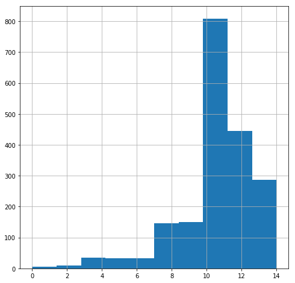

```python
#histogram for all dog ratings
% matplotlib inline
tweets_clean[tweets_clean.rating_numerator < 20].rating_numerator.hist(figsize = (8,8));
```

Analyzing our graph that we've just produced, we can see that the vast majority of dogs have extremely high ratings and are very good dogs! This is a confirmation of the worldview that I held before I started this project. It also appears that this distribution is skewed to the left.